# PART 1 - Loading and preprocessing the data

## PART 1 - Loading and preprocessing the data

### (1) Load the required data

The following statement is used to load the data using read.csv().

Note: It is assumed that the file activity.csv is in the current working directory. File can be downloaded from https://d396qusza40orc.cloudfront.net/repdata%2Fdata%2Factivity.zip

```r
Activity_Monitoring_Data <- read.csv('activity.csv', header=TRUE, sep = ",")
```

### (2) Process / transform the data into a format suitable for analysis.

The date field is converted to Date class, interval field to Factor class, weekdays from date attribute, compute day type.

```r
Activity_Monitoring_Data$date <- as.Date(Activity_Monitoring_Data$date, format = "%Y-%m-%d")
Activity_Monitoring_Data$interval <- as.factor(Activity_Monitoring_Data$interval)

# Compute the weekdays from the date attribute
Activity_Monitoring_Data <- data.frame(date=Activity_Monitoring_Data$date,
                 weekday=tolower(weekdays(Activity_Monitoring_Data$date)),
                 steps=Activity_Monitoring_Data$steps,
                 interval=Activity_Monitoring_Data$interval)

# Compute the day type (indicate either weekend or weekday)
Activity_Monitoring_Data <- cbind(Activity_Monitoring_Data,
            daytype=ifelse(Activity_Monitoring_Data$weekday == "saturday" |
                             Activity_Monitoring_Data$weekday == "sunday", "weekend","weekday"))

# Create the final data frame
Activity_Data <- data.frame(date=Activity_Monitoring_Data$date,
                       weekday=Activity_Monitoring_Data$weekday,
                       daytype=Activity_Monitoring_Data$daytype,
                       interval=Activity_Monitoring_Data$interval,
                       steps=Activity_Monitoring_Data$steps)

str(Activity_Data) #  check the final dataset using str() method
```

```
## 'data.frame':    17568 obs. of  5 variables:
##  $ date    : Date, format: "2012-10-01" "2012-10-01" ...
##  $ weekday : Factor w/ 7 levels "friday","monday",..: 2 2 2 2 2 2 2 2 2 2 ...
##  $ daytype : Factor w/ 2 levels "weekday","weekend": 1 1 1 1 1 1 1 1 1 1 ...
##  $ interval: Factor w/ 288 levels "0","5","10","15",..: 1 2 3 4 5 6 7 8 9 10 ...
##  $ steps   : int  NA NA NA NA NA NA NA NA NA NA ...
```

```r
# Clear the workspace
rm(Activity_Monitoring_Data)
```

Summary of the final dataset.

```r
library(xtable)
summary(Activity_Data)
```

```
##       date                 weekday        daytype         interval
##  Min.   :2012-10-01   friday   :2592   weekday:12960   0      :   61
##  1st Qu.:2012-10-16   monday   :2592   weekend: 4608   5      :   61
##  Median :2012-10-31   saturday :2304                   10     :   61
##  Mean   :2012-10-31   sunday   :2304                   15     :   61
##  3rd Qu.:2012-11-15   thursday :2592                   20     :   61
##  Max.   :2012-11-30   tuesday  :2592                   25     :   61
##                       wednesday:2592                   (Other):17202
##      steps
##  Min.   :  0.00
##  1st Qu.:  0.00
##  Median :  0.00
##  Mean   : 37.38
##  3rd Qu.: 12.00
##  Max.   :806.00
##  NA's   :2304
```

## PART 2 - What is the mean total number of steps taken per day?

For this part of the assignment, the missing values in the dataset are ignored. First, we calculate the total number of steps taken per day.

```r
# Compute the total number of steps each day (NA values removed)
total_steps <- aggregate(Activity_Data$steps,by=list(Activity_Data$date), FUN=sum, na.rm=TRUE)

# Rename the attributes
names(total_steps) <- c("date", "total")
```

Then, we make a histogram of the total number of steps taken each day.

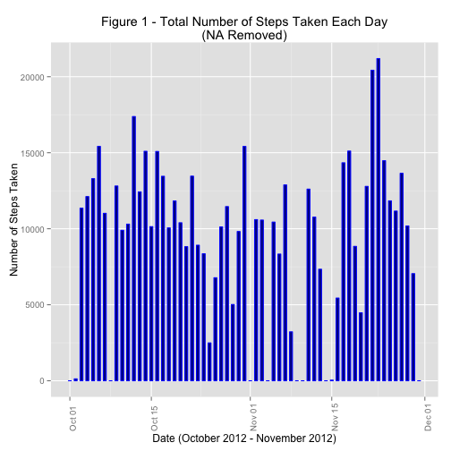

```r
library(ggplot2)

ggplot(total_steps, aes(date, total)) +
  geom_bar(stat = "identity", colour = "blue",fill = "dark blue", width = 0.5) +
  labs(title = "Figure 1 - Total Number of Steps Taken Each Day\n(NA Removed)", x = "Date (October 2012 - November 2012)", y = "Number of Steps Taken") +
  theme(axis.text.x = element_text(angle = 90,hjust = 0))
```

Lastly, we calculate the mean and median of the total number of steps taken per day.

```r
totalsteps_mean <- mean(total_steps$total)
totalsteps_median <- median(total_steps$total)
```

The mean is **9354.23** and the median is **10395**.

## PART 3 - What is the average daily activity pattern?

We calculate the aggregation of steps by intervals of 5-minutes and convert the intervals as integers and save them in a data frame called *steps_by_interval*.

```r
steps_by_interval <- aggregate(Activity_Data$steps,by = list(interval= Activity_Data$interval), FUN=mean, na.rm=TRUE)
steps_by_interval$interval <-
        as.integer(levels(steps_by_interval$interval)[steps_by_interval$interval])
colnames(steps_by_interval) <- c("interval", "steps")
```

A time series plot (i.e. type = “l”) of the 5-minute interval (x-axis) and the average number of steps taken, averaged across all days (y-axis) is made.

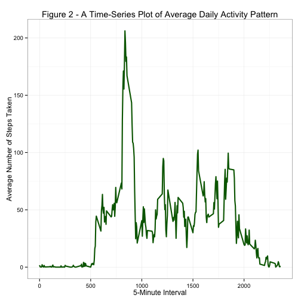

```r
library(ggplot2)
ggplot(steps_by_interval, aes(x=interval, y=steps)) + geom_line(color="dark green", size=1) + labs(title="Figure 2 - A Time-Series Plot of Average Daily Activity Pattern", x="5-Minute Interval", y="Average Number of Steps Taken") + theme_bw()
```

Which 5-minute interval, on average across all the days in the dataset, contains the maximum number of steps?

```r
steps_by_interval[which.max(steps_by_interval$steps),]
```

```
##     interval    steps
## 104      835 206.1698
```

The **835<sup>th^</sup>** (8:35am) interval has maximum **206** steps.